# Évaluation n°1 — Suites numériques

# Évaluation n°1

**Classe :** Terminale **Date :** Mardi 9 Septembre

**Question 1 (1 point).** Donner la définition d’une suite arithmétique.

**Solution**

Une suite $(u_n)_{n\in \mathbb{N}}$ est arithmétique s’il existe un réel $r$, appelé raison de la suite, tel que pour tout $n\in \mathbb{N}$, on a $u_{n+1}=u_n+r$.

**Question 2 (3 points).** Donner la formule de la somme des $n$ premiers entiers naturels puis la démontrer.

**Solution**

Pour tout $n\in \mathbb{N}^*$, $\displaystyle\sum_{i=1}^n i=1+2+3+...+n=\dfrac{n(n+1)}{2}$

**Démonstration :** Méthode de Gauss (mathématicien allemand du XVIII$^{\text{e}}$-XIX$^{\text{e}}$ siècle)

On écrit la somme dans l’ordre croissant des termes puis dans l’ordre décroissant des termes :

$S=1+2+3+...+(n-2)+(n-1)+n$

$S=n+(n-1)+(n-2)+...3+2+1$

Par somme, membre à membre, on obtient :

$2S=(1+n)+(1+n)+(1+n)+...+(1+n)+(1+n)+(1+n)$

$2S=n(n+1)$

Donc $S=\dfrac{n(n+1)}{2}$

**Question 3 (2 points).** Soit $(u_n)$ la suite définie pour $n \in \mathbb{N}$ par $u_n=\dfrac{3}{2^n}$. La suite $(u_n)$ est-elle géométrique ? Si oui, préciser sa raison.

**Solution**

Soit $n \in \mathbb{N}$, $u_{n+1}=\dfrac{3}{2^{n+1}}=\dfrac{3}{2 \times 2^n}=\dfrac{1}{2} \times \dfrac{3}{2^n}=\dfrac{1}{2}u_n$

Donc, $(u_n)$ est une suite géométrique de raison $q=\dfrac{1}{2}$.

**Question 4 (2 points).** Calculer la somme : $S=2-6+18-54+...+118\,098$

**Solution**

$S$ est la somme des premiers termes de la suite géométrique $(v_n)$ de premier terme $v_0=2$ et de raison $q=-3$. Ainsi $\forall n \in \mathbb{N},~v_n=2\times(-3)^n$. L’indice du dernier terme est 10 car $2\times (-3)^{10}=118\,098$

$$\begin{align*}
S&=v_0+v_1+v_2+...+v_{10}\\
&=v_0+v_0\times q + v_0 \times q^2+...+v_0 \times q^{10} \\
&=v_0(1+q+q^2+...+q^{10}) \\
&=v_0 \dfrac{1-q^{11}}{1-q}\\
&=2\times\dfrac{1-(-3)^{11}}{1-(-3)}\\
&=88574
\end{align*}$$

**Question 5 (3 points).** Étudier les variations de la suite $(u_n)$ telle que
$$\forall n \in \mathbb{N},~ u_n=\dfrac{n+1}{n+4}$$

**Solution**

**Méthode 1 :**

Soit $n \in \mathbb{N}$,

$$\begin{align*}
u_{n+1}-u_n&=\dfrac{n+2}{n+5}-\dfrac{n+1}{n+4}\\
&=\dfrac{(n+2)(n+4)-(n+1)(n+5)}{(n+5)(n+4)}\\
&=\dfrac{n^2+6n+8-n^2-6n-5}{(n+5)(n+4)}\\
&=\dfrac{3}{(n+5)(n+4)}
\end{align*}$$

Or, $n+5>0$ et $n+4>0$ donc $u_{n+1}-u_n>0$

Donc la suite $(u_n)$ est croissante.

**Méthode 2 :**

Soit $f$ la fonction associée à $(u_n)$. $f$ est définie sur $[0;+\infty[$ par $f(x)=\dfrac{x+1}{x+4}$. Ainsi, $f(n)=u_{n}$.

$f$ est dérivable sur $[0;+\infty[$, et pour $x \in [0;+\infty[$,

$f'(x)=\dfrac{1 \times (x+4)-(x+1) \times 1}{(x+4)^2}=\dfrac{3}{(x+4)^2}>0$

Donc, la suite $(u_n)$ est croissante.

**Question 6 (2 points).** Soit $(v_n)$ la suite définie par $v_0=0,5$ et pour tout entier naturel $n$,
$$v_{n+1}=1+\dfrac{1}{v_n}$$

On donne la représentation graphique de la fonction $f$ définie sur $]0;+\infty[$ par $f(x)=1+\dfrac{1}{x}$. Représenter graphiquement les quatre premiers termes de la suite (laisser apparents les traits de construction).

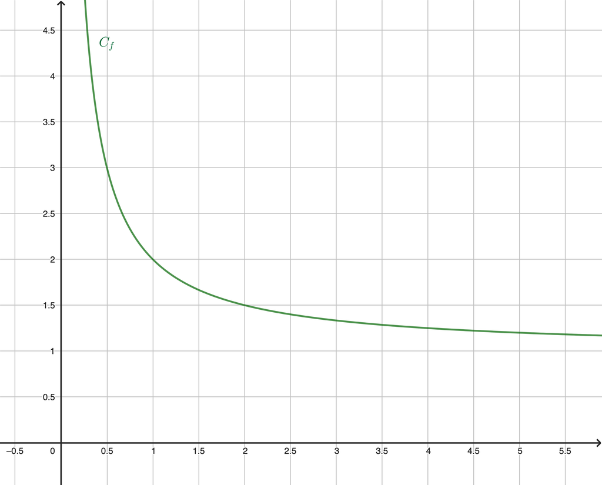

**Solution**

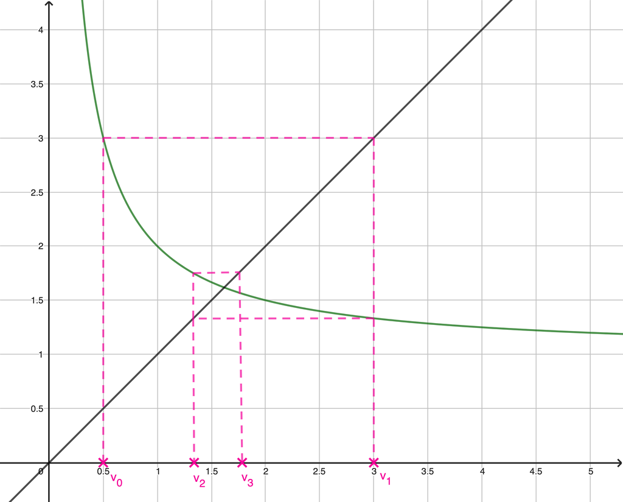